Análise de atributos dos imóveis

Abaixo, serão gerados gráficos de coluna empilhada de base 100 para analisarmos as características dos imóveis segundo o agrupamento realizado na etapa de pré-processamento, que leva em conta as informações de localização e preço por sqft. O intuito dessa visualização é identificarmos a proporção de cada atributo dentro dos 4 grupos existentes. Além disso, será avaliado o preço médio por cada categoria dos atributos.

**Informações sobre imóveis com e sem vista para o mar:**

- 0: sem vista
- 1: com vista

```r
#GRÁFICO DE COLUNAS EMPILHADAS - VISUALIZAÇÃO POR GRUPO
#Agrupando as informações para obtermos o % de cada valor 0 e 1
waterfront_tx <- df %>%
  group_by(grupo, waterfront) %>%
  summarise(count = n()) %>%
  group_by(grupo) %>%
  mutate(proporcao = count / sum(count))

#Gerando o plot da coluna empilhada de base 100 com rótulos
plotW1 <- ggplot(waterfront_tx, aes(x = grupo, y = proporcao, fill = as.factor(waterfront))) +
  geom_bar(stat = "identity") +
  geom_text(aes(label = scales::percent(proporcao, accuracy = 0.1)), position = position_fill(vjust =   0.5), size = 5) +
  labs(title = "Percentual de imóveis com vista para o mar por grupo",
       x = "Grupo",
       y = NULL)+
  guides(fill = FALSE)+
  scale_fill_manual(values = paleta)+
    theme_minimal()

#GRÁFICO DO PREÇO MÉDIO POR CATEGORIA DE WATERFRONT
#Calcular a média do preço para cada categoria
media_priceW <- df %>%
  group_by(waterfront) %>%
  summarise(preco_medio = mean(price, na.rm = TRUE))

#Criando o gráfico de barras horizontais
plotW2 <- ggplot(media_priceW, aes(x = preco_medio, y = waterfront, fill = waterfront)) +
  geom_bar(stat = "identity") +
  geom_text(aes(label = scales::dollar(preco_medio)), hjust = 1.1, size = 5) +
  labs(title = "Preço médio por imóvel com/sem vista para o mar",
       x = "Preço médio",
       y = "Vista para o mar",
       fill = "Waterfront")+
  scale_fill_manual(values = paleta)+
    theme_minimal()
```

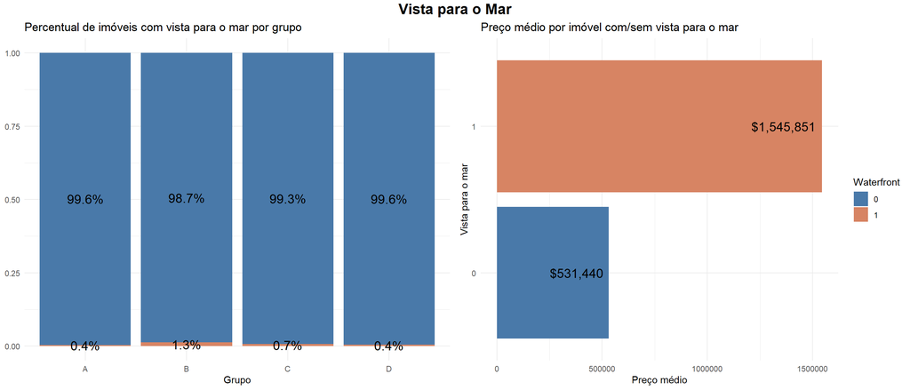

```r
#Unindo os gráficos sobre vista para o mar
grid.arrange(plotW1, plotW2,
            ncol = 2,
            top = textGrob("Vista para o Mar", gp = gpar(fontsize = 16, fontface = "bold")))
```

No primeiro gráfico, é possível identificar que o grupo B é o que mais possui imóveis com vista para o mar, o que está de acordo com a visualização em mapa do agrupamento, visto que esse grupo tem maior área de praia. Como também é de se esperar, esses imóveis têm o preço médio mais elevado.

**Informações sobre imóveis renovados e não renovados:**

- 0: não renovados
- 1: renovados

```r
#GRÁFICO DE COLUNAS EMPILHADAS - VISUALIZAÇÃO POR GRUPO
#Agrupando as informações para obtermos o % de cada valor 0 e 1
renovated_tx <- df %>%
  group_by(grupo, renovated) %>%
  summarise(count = n()) %>%
  group_by(grupo) %>%
  mutate(proporcao = count / sum(count))

#Gerando o plot da coluna empilhada de base 100 com rótulos
plotR1 <- ggplot(renovated_tx, aes(x = grupo, y = proporcao, fill = as.factor(renovated))) +
  geom_bar(stat = "identity") +
  geom_text(aes(label = scales::percent(proporcao, accuracy = 0.1)), position = position_fill(vjust =   0.5), size = 5) +
  labs(title = "Percentual de imóveis renovados por grupo",
       x = "Grupo",
       y = NULL)+
  guides(fill = FALSE)+
  scale_fill_manual(values = paleta)+
    theme_minimal()

#GRÁFICO DO PREÇO MÉDIO POR CATEGORIA DE RENOVATED
#Calcular a média do preço para cada categoria
media_pricer <- df %>%
  group_by(renovated) %>%
  summarise(preco_medio = mean(price, na.rm = TRUE))

#Criando o gráfico de barras horizontais
plotR2 <- ggplot(media_pricer, aes(x = preco_medio, y = renovated, fill = renovated)) +
  geom_bar(stat = "identity") +
  geom_text(aes(label = scales::dollar(preco_medio)), hjust = 1.1, size = 5) +
  labs(title = "Preço médio por imóvel renovado e não renovado",
       x = "Preço médio",
       y = "Renovado",
       fill = "Renovated")+
  scale_fill_manual(values = paleta)+
    theme_minimal()
```

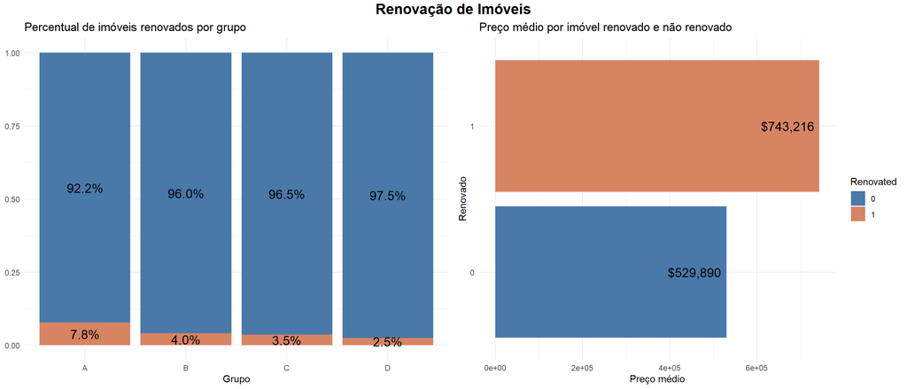

```r
#Unindo os gráficos sobre renovação de imóveis
grid.arrange(plotR1, plotR2,
            ncol = 2,
            top = textGrob("Renovação de Imóveis", gp = gpar(fontsize = 16, fontface = "bold")))
```

Nos gráficos acima, verificamos que o grupo A é que possui maior percentual de imóveis renovados, o que também está em linha com o esperado, visto que é o grupo com maior preço por ft quadrado.

**Informações sobre número de quartos:**

Para facilitar a visualização, optamos por agrupar numa única categoria imóveis com mais de 5 quartos no primeiro gráfico, visto que o número máximo dessa variável é de 33 quartos.

```r
#GRÁFICO DE COLUNAS EMPILHADAS - VISUALIZAÇÃO POR GRUPO

#Calculando a proporção de imóveis por grupo e categoria de quartos
bedrooms_tx <- df %>%
  group_by(grupo, categoria_quartos) %>%
  summarise(count = n()) %>%
  group_by(grupo) %>%
  mutate(proporcao = count / sum(count))

#Coluna para indicar se o rótulo deve ser exibido (ocultando para uma visualização mais limpa)
bedrooms_tx$exibir_rotulo <- bedrooms_tx$proporcao >= 0.02

#Criando o gráfico de colunas empilhadas base 100 com rótulos de percentual (1 casa decimal)
plotbd1 <- ggplot(bedrooms_tx, aes(x = grupo, y = proporcao, fill = categoria_quartos)) +
  geom_bar(stat = "identity") +
  geom_text(aes(label = ifelse(exibir_rotulo, scales::percent(proporcao, accuracy = 0.1), "")),
            position = position_fill(vjust = 0.5), size = 5) +
  labs(title = "Percentual de imóveis com n quartos por grupo",
       x = "Grupo",
       y = NULL,
       fill = "Nº de quartos")+
  guides(fill = FALSE)+
  scale_fill_manual(values = paleta)+
    theme_minimal()

#GRÁFICO DO PREÇO MÉDIO POR CATEGORIA DE NÚMERO DE QUARTOS
#Calcular a média do preço para cada categoria de quartos
media_preco_bedrooms <- df %>%
  group_by(categoria_quartos) %>%
  summarise(preco_medio = mean(price))%>%
  mutate(categoria_quartos = factor(categoria_quartos, levels = categoria_quartos))

#Criando o gráfico de barras horizontais
plotbd2 <- ggplot(media_preco_bedrooms, aes(x = preco_medio, y = categoria_quartos, fill = categoria_quartos)) +
  geom_bar(stat = "identity") +
  geom_text(aes(label = scales::dollar(preco_medio)), hjust = 1.1, size = 5) +
  labs(title = "Preço médio por número de quartos",
       x = "Preço médio",
       y = "Nº de quartos",
       fill = "Nº de quartos")+
  scale_fill_manual(values = paleta)+
    theme_minimal()
```

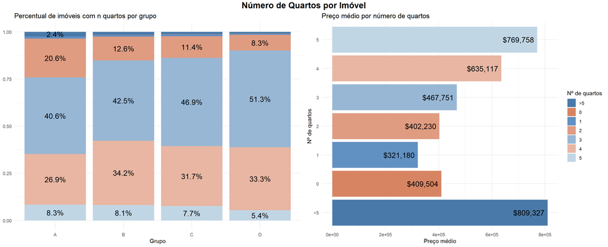

```r
#Unindo os gráficos sobre número de quartos
grid.arrange(plotbd1, plotbd2,
            ncol = 2,
            top = textGrob("Número de Quartos por Imóvel", gp = gpar(fontsize = 16, fontface = "bold")))
```

**Informações sobre número de andares:**

```r
#GRÁFICO DE COLUNAS EMPILHADAS - VISUALIZAÇÃO POR GRUPO
#Calculando a proporção de imóveis por grupo e número de andares
floors_tx <- df %>%
  group_by(grupo, floors) %>%
  summarise(count = n()) %>%
  group_by(grupo) %>%
  mutate(proporcao = count / sum(count))

#Coluna para indicar se o rótulo deve ser exibido (ocultando para uma visualização mais limpa)
floors_tx$exibir_rotulo <- floors_tx$proporcao >= 0.01

#Criando o gráfico de colunas empilhadas base 100 com rótulos de percentual (1 casa decimal)
plotf1 <- ggplot(floors_tx, aes(x = grupo, y = proporcao, fill = as.factor(floors))) +
  geom_bar(stat = "identity") +
   geom_text(aes(label = ifelse(exibir_rotulo, scales::percent(proporcao, accuracy = 0.1), "")),
            position = position_fill(vjust = 0.5), size = 5) +
  labs(title = "% de imóveis com n andares por grupo",
       x = "Grupo",
       y = NULL)+
  guides(fill = FALSE)+
  scale_fill_manual(values = paleta)+
    theme_minimal()

#GRÁFICO DO PREÇO MÉDIO POR NÚMERO DE ANDARES
#Calcular a média do preço para cada número de andares
media_preco_floors <- df %>%
  group_by(floors) %>%
  summarise(preco_medio = mean(price))%>%
  mutate(floors = factor(floors, levels = floors))

#Criar o gráfico de barras horizontais
plotf2 <- ggplot(media_preco_floors, aes(x = preco_medio, y = floors, fill = floors)) +
  geom_bar(stat = "identity") +
  geom_text(aes(label = scales::dollar(preco_medio)), hjust = 1.1, size = 5) +
  labs(title = "Preço médio por número de andares",
       x = "Preço médio",
       y = "Nº de andares",
       fill = "Nº de andares")+
  scale_fill_manual(values = paleta)+
    theme_minimal()
```

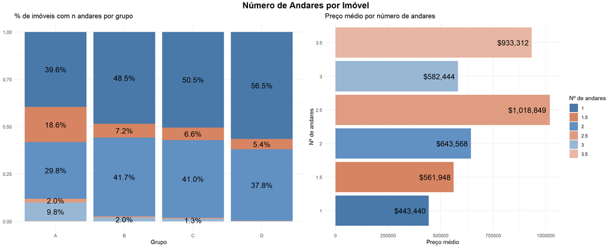

```r
#Unindo os gráficos sobre número de andares
grid.arrange(plotf1, plotf2,
            ncol = 2,
            top = textGrob("Número de Andares por Imóvel", gp = gpar(fontsize = 16, fontface = "bold")))
```